# Phy 481 homework #7

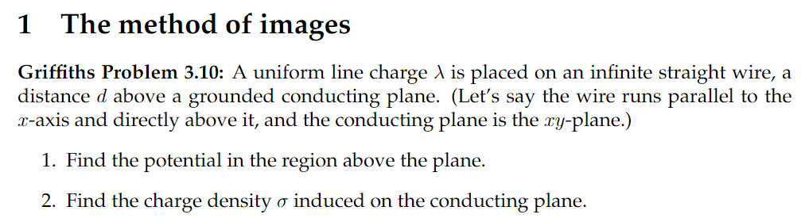

Due to uniqueness, we can use the method of images to show how the grounded plane responds to the line charge density $\lambda$ at height $d$ above it. A line charge density of $-\lambda$ at $-d$ would counteract the electric potential made by this.

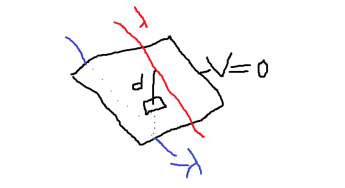

1. In this situation, $\frac{dV}{dx}=-E_x=0$ since there the charge distribution is infinitely long in the $x$ direction.

Using cylinder gaussian shells, we can find the electric field associated with any point due to a single charge distribution

$$ \nabla \cdot E = \frac{Q_{enc}}{\epsilon_0} \\ 2\pi r l E = \frac{\lambda l}{\epsilon_0} \\ E(r) = \frac{\lambda}{2\pi r \epsilon_0} \hat r $$

And the associated voltage is

$$ \Delta V = -\int_O^r E(r)dr = -\frac{\lambda}{2\pi \epsilon_0} \int_O^r \frac{1}{r} dr = -\frac{\lambda}{2\pi \epsilon_0} \ln\left(\frac{r}{O} \right) = \frac{\lambda}{2\pi \epsilon_0} \ln\left(\frac{O}{r} \right) $$

The term $r$ here is distance from the charge distribution, while $O$ is a point where voltage is zero. By superposition, we can represent each charge distribution as this $\Delta V$ if we find the distance from each line in terms of $y$ and $z$. $r_1$ is for $\lambda$ while $r_2$ is for $-\lambda$

$$ r_1 = \sqrt{y^2 + (z-d)^2} \\ r_2 = \sqrt{y^2 + (z+d)^2} $$

$$ V(r_1, r_2) = \Delta V_1 + \Delta V_2 = \frac{\lambda}{2\pi \epsilon_0} \left[ \ln\left(\frac{O}{r_1} \right) - \ln\left(\frac{O}{r_2} \right)\right] \\= \frac{\lambda}{2\pi \epsilon_0}\ln\left(\frac{O/r_1}{O/r_2} \right) = \frac{\lambda}{2\pi \epsilon_0}\ln\left(\frac{r_2}{r_1} \right)\\ V(x,y)= \frac{\lambda}{2\pi \epsilon_0}\ln\left(\frac{\sqrt{y^2 + (z+d)^2}}{\sqrt{y^2 + (z-d)^2}} \right) \\ = \frac{\lambda}{4\pi \epsilon_0}\ln\left(\frac{{y^2 + (z+d)^2}}{{y^2 + (z-d)^2}} \right) $$

2. Using $\hat n = \hat z$,

$$ \sigma = -\epsilon_0 \frac{\partial V}{\partial z} $$

Let's evaluate the derivative at $z=0$

$$ \sigma = -\epsilon_0 \frac{\lambda}{4\pi \epsilon_0} \frac{\partial }{\partial z} \left[\ln\left(\frac{{y^2 + (z+d)^2}}{{y^2 + (z-d)^2}} \right)\right]_{z=0} $$

$$ = \frac{\lambda}{4\pi} \left[\frac{2d}{y^2+d^2} - \frac{-2d}{y^2+d^2} \right] \\ = -\frac{\lambda}{\pi } \frac{d}{y^2 + d^2} $$

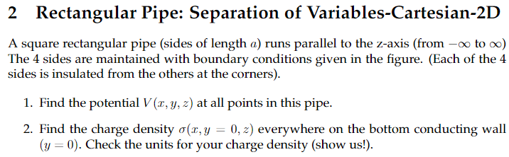

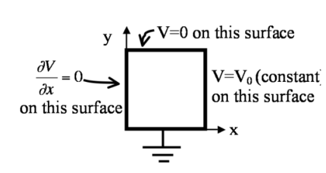

1. Lets do it!

Can safely ignore $z$ due to $z$ invariance

$$ \nabla^2 V = \frac{\partial^2 V}{\partial x^2} + \frac{\partial^2 V}{\partial y^2} = 0 \\ $$

Using $V(x,y) = X(x)Y(y)$

$$ =Y \frac{\partial^2 X}{\partial x^2} + X \frac{\partial^2 Y} {\partial Y^2} \\\rightarrow \frac{1}{X}\frac{\partial^2 X}{\partial x^2} + \frac{1}{Y} \frac{\partial^2 YV}{\partial Y^2} = 0 \\ \frac{1}{X}\frac{\partial^2 X}{\partial x^2} = - \frac{1}{Y} \frac{\partial^2 YV}{\partial Y^2} $$

Each term is constant as the other varies.

$$ \frac{1}{X}\frac{\partial^2 X}{\partial x^2} = k^2 \\ \frac{1}{Y} \frac{\partial^2 YV}{\partial Y^2} = -k^2 \\ X(x) = Ae^{kx} + Be^{-kx} \\ Y(y) = C\cos(ky)+D\sin(ky) $$

These are standard second order differential equations. We can actually swap which is sine/cosine dependant and which is exponential. I chose these since they fit well with the the left wall boundary condition.

Apply boundary conditions

$$ Y(0) = 0 \rightarrow C = 0\\ Y(a) = 0 \rightarrow ka = n\pi \rightarrow k = \frac{n\pi}{a} \\ Y(y) = D\sin(ky) = D\sin\left(\frac{n\pi}{a}y\right) $$ Sine is zero at multiples of $\pi$. Next we'll apply the left wall boundary condition. Since it is dependant on $x$, $Y$ will be constant.

$$ \left.\frac{\partial V}{\partial x}\right|_{x=0} = 0 \rightarrow Yk\left[Ae^{k(0)}-Be^{-k(0)} \right] = 0 \rightarrow Yk[A-B]=0\rightarrow A=B \\ X(x) = Ae^{kx}+Ae^{-kx} = 2A \cosh(kx)\\ V(x,y) = \sum_n D_n \cosh\left(\frac{n\pi}{a}x\right) \sin\left( \frac{n\pi}{a} y\right) $$ Where we absorb $2A$ into $D_n$ without loss of generality

To find the value of each $D_n$, we'll apply forier's trick using sine and integrating over the relevant length $[0,a]$. We'll also apply $V(x=a,y) = V_0 to help solve for the coefficients.

$$ V(x=a, y) = V_0 = \sum_n D_n \cosh(n\pi) \sin\left(\frac{n\pi}{a}y \right) \\ $$ Multiply by $\sin(\frac{m\pi}{a}y)$ and integrate $$ \int_0^a V_0 \sin\left(\frac{m\pi}{a}y\right)dy = \sum_n D_n \cosh\left(n\pi\right) \int_0^a \sin\left(\frac{n\pi}{a} y\right)\sin\left(\frac{m\pi}{a} y\right)dy \\ $$ LHS

$$ \int_0^a V_0 \sin\left(\frac{m\pi}{a}y\right)dy =\frac{aV_0}{m \pi}-\frac{aV_0}{m \pi}\cos(m \pi) \\ =\begin{cases} 0 & m = 0\pmod{2} \\ \frac{-2aV_0}{m\pi} & m=1\pmod{2} \\ \end{cases} $$

RHS

$$ \sum_n D_n \cosh\left(n\pi\right) \int_0^a \sin\left(\frac{n\pi}{a} y\right)\sin\left(\frac{m\pi}{a} y\right)dy=\frac{a}{2}C_m \cosh(m\pi) $$

$D_m =0$ for even values of $m$, otherwise we have

$$ \frac{-2aV_0}{m\pi} = \frac{a}{2} C_m \cosh(m\pi) \\ C_m = \frac{4V_0}{m\pi \cosh(m\pi)} $$ Now we have our voltage!

$$ V(x,y) = \frac{4V_0}{\pi} \sum_{n=1,3,5\dots} \frac{\cosh( \frac{n\pi}{a}x)}{\cosh(n\pi)} \frac{\sin(\frac{n\pi}{a} y)}{n} $$

Here's what this looks like:

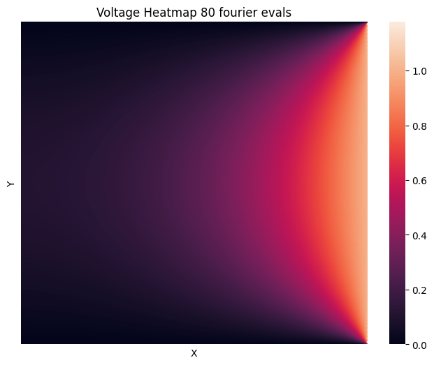

```python
import numpy as np
from numpy import cosh, pi, sin
import matplotlib.pyplot as plt
import seaborn as sns
from seaborn import cm

fourier_size = 80 # watch out for overflow
V0 = 1
a = 1

n2 = 2000
x = np.linspace(0, a, n2)
y = np.linspace(0, a, n2)
X, Y = np.meshgrid(x, y)

def phi(x, y, fourier_size, params):
    V0, a = params

    potential = 0

    for i in range(fourier_size):
        n = 2*i + 1
        potential += cosh(n*pi*x/a) * sin(n*pi*y/a)/ (n*cosh(n*pi))

    return 4*V0/pi * potential


params = (V0, a)

meshout = phi(X, Y, fourier_size, params)

plt.figure(figsize=(8, 6))
sns.heatmap(meshout, cmap=cm.rocket, xticklabels=False, yticklabels=False)
plt.title(f'Voltage Heatmap {fourier_size} fourier evals')
plt.xlabel('X')
plt.ylabel('Y')

plt.show()
```

2. $\hat n = \hat x$

$$ \sigma = -\epsilon_0\left.\frac{\partial V}{\partial x}\right|_{y=0} \\ = -\epsilon_0\frac{4V_0}{\pi} \sum_{n=1,3,5\dots} \frac{\sin(0)}{n\cosh(n\pi)} \frac{\partial}{\partial x}\cosh( \frac{n\pi}{a}x) $$

Since $\sin(0) = 0$, the result is zero.

Units: $$ [\sigma] = [C \cdot m^{-2}] \\ [\epsilon_0] = [C^2 \cdot N^{-1} \cdot m^{-2}] \\ [V] = [N \cdot m \cdot C^{-1}] \\ $$ For derivative, use $[m^{-1}]$

$$ [\epsilon_0] \left[\frac{\partial}{\partial n}\right] [V] = [C^2N^{-1}m^{-2} Nm C^{-1} m^{-1}] =[Cm^{-2}] = [\sigma] $$

ak_HW07-Method-of-relaxation-1D.ipynb